# Risk Factor Analysis

## Outcome Variable

**Outcome Variable:** pers_wasted624

## Predictor Variables

**Intervention Variable:** ever_stunted06

**Adjustment Set:**

- sex
- arm
- enstunt
- month
- brthmon
- vagbrth
- single
- W_gagebrth
- W_birthwt
- W_birthlen
- W_mage
- W_mhtcm
- W_meducyrs
- W_feducyrs
- W_parity
- delta_month
- delta_brthmon
- delta_vagbrth
- delta_single
- delta_W_gagebrth
- delta_W_birthwt
- delta_W_birthlen
- delta_W_mage
- delta_W_mhtcm
- delta_W_meducyrs
- delta_W_feducyrs
- delta_W_parity

## Stratifying Variables

The analysis was stratified on these variable(s):

- studyid
- country

## Data Summary

| studyid | country | ever_stunted06 | pers_wasted624 | n_cell | n |
| --- | --- | --- | --- | --- | --- |
| ki0047075b-MAL-ED | BANGLADESH | 0 | 0 | 149 | 239 |
| ki0047075b-MAL-ED | BANGLADESH | 0 | 1 | 10 | 239 |
| ki0047075b-MAL-ED | BANGLADESH | 1 | 0 | 72 | 239 |
| ki0047075b-MAL-ED | BANGLADESH | 1 | 1 | 8 | 239 |
| ki0047075b-MAL-ED | BRAZIL | 0 | 0 | 163 | 202 |
| ki0047075b-MAL-ED | BRAZIL | 0 | 1 | 2 | 202 |
| ki0047075b-MAL-ED | BRAZIL | 1 | 0 | 37 | 202 |
| ki0047075b-MAL-ED | BRAZIL | 1 | 1 | 0 | 202 |
| ki0047075b-MAL-ED | INDIA | 0 | 0 | 139 | 234 |
| ki0047075b-MAL-ED | INDIA | 0 | 1 | 15 | 234 |
| ki0047075b-MAL-ED | INDIA | 1 | 0 | 67 | 234 |
| ki0047075b-MAL-ED | INDIA | 1 | 1 | 13 | 234 |
| ki0047075b-MAL-ED | NEPAL | 0 | 0 | 194 | 234 |
| ki0047075b-MAL-ED | NEPAL | 0 | 1 | 1 | 234 |
| ki0047075b-MAL-ED | NEPAL | 1 | 0 | 38 | 234 |
| ki0047075b-MAL-ED | NEPAL | 1 | 1 | 1 | 234 |
| ki0047075b-MAL-ED | PERU | 0 | 0 | 143 | 264 |
| ki0047075b-MAL-ED | PERU | 0 | 1 | 0 | 264 |
| ki0047075b-MAL-ED | PERU | 1 | 0 | 119 | 264 |
| ki0047075b-MAL-ED | PERU | 1 | 1 | 2 | 264 |
| ki0047075b-MAL-ED | SOUTH AFRICA | 0 | 0 | 157 | 258 |
| ki0047075b-MAL-ED | SOUTH AFRICA | 0 | 1 | 2 | 258 |
| ki0047075b-MAL-ED | SOUTH AFRICA | 1 | 0 | 99 | 258 |
| ki0047075b-MAL-ED | SOUTH AFRICA | 1 | 1 | 0 | 258 |
| ki0047075b-MAL-ED | TANZANIA, UNITED REPUBLIC OF | 0 | 0 | 144 | 244 |
| ki0047075b-MAL-ED | TANZANIA, UNITED REPUBLIC OF | 0 | 1 | 0 | 244 |
| ki0047075b-MAL-ED | TANZANIA, UNITED REPUBLIC OF | 1 | 0 | 100 | 244 |
| ki0047075b-MAL-ED | TANZANIA, UNITED REPUBLIC OF | 1 | 1 | 0 | 244 |
| ki1000108-CMC-V-BCS-2002 | INDIA | 0 | 0 | 169 | 368 |
| ki1000108-CMC-V-BCS-2002 | INDIA | 0 | 1 | 11 | 368 |

[output cut: 118 more lines]

The following strata were considered:

- studyid: ki0047075b-MAL-ED, country: BANGLADESH
- studyid: ki0047075b-MAL-ED, country: BRAZIL
- studyid: ki0047075b-MAL-ED, country: INDIA
- studyid: ki0047075b-MAL-ED, country: NEPAL
- studyid: ki0047075b-MAL-ED, country: PERU
- studyid: ki0047075b-MAL-ED, country: SOUTH AFRICA
- studyid: ki0047075b-MAL-ED, country: TANZANIA, UNITED REPUBLIC OF
- studyid: ki1000108-CMC-V-BCS-2002, country: INDIA
- studyid: ki1000108-IRC, country: INDIA
- studyid: ki1000109-EE, country: PAKISTAN
- studyid: ki1000109-ResPak, country: PAKISTAN
- studyid: ki1000304-VITAMIN-A, country: INDIA
- studyid: ki1000304b-SAS-CompFeed, country: INDIA
- studyid: ki1000304b-SAS-FoodSuppl, country: INDIA
- studyid: ki1017093-NIH-Birth, country: BANGLADESH
- studyid: ki1017093b-PROVIDE, country: BANGLADESH
- studyid: ki1017093c-NIH-Crypto, country: BANGLADESH
- studyid: ki1066203-TanzaniaChild2, country: TANZANIA, UNITED REPUBLIC OF
- studyid: ki1101329-Keneba, country: GAMBIA
- studyid: ki1112895-Burkina Faso Zn, country: BURKINA FASO
- studyid: ki1112895-Guatemala BSC, country: GUATEMALA
- studyid: ki1113344-GMS-Nepal, country: NEPAL
- studyid: ki1114097-CMIN, country: BANGLADESH
- studyid: ki1114097-CMIN, country: BRAZIL
- studyid: ki1114097-CMIN, country: GUINEA-BISSAU
- studyid: ki1114097-CMIN, country: PERU
- studyid: ki1114097-CONTENT, country: PERU
- studyid: ki1119695-PROBIT, country: BELARUS
- studyid: ki1126311-ZVITAMBO, country: ZIMBABWE
- studyid: ki1135781-COHORTS, country: GUATEMALA
- studyid: ki1135781-COHORTS, country: INDIA
- studyid: ki1135781-COHORTS, country: PHILIPPINES
- studyid: ki1148112-iLiNS-DOSE, country: MALAWI
- studyid: ki1148112-iLiNS-DYAD-M, country: MALAWI
- studyid: ki1148112-LCNI-5, country: MALAWI
- studyid: kiGH5241-JiVitA-3, country: BANGLADESH
- studyid: kiGH5241-JiVitA-4, country: BANGLADESH

### Dropped Strata

Some strata were dropped due to rare outcomes:

- studyid: ki0047075b-MAL-ED, country: BRAZIL
- studyid: ki0047075b-MAL-ED, country: NEPAL
- studyid: ki0047075b-MAL-ED, country: PERU
- studyid: ki0047075b-MAL-ED, country: SOUTH AFRICA
- studyid: ki0047075b-MAL-ED, country: TANZANIA, UNITED REPUBLIC OF
- studyid: ki1112895-Burkina Faso Zn, country: BURKINA FASO
- studyid: ki1112895-Guatemala BSC, country: GUATEMALA
- studyid: ki1114097-CMIN, country: BANGLADESH
- studyid: ki1114097-CMIN, country: BRAZIL
- studyid: ki1114097-CMIN, country: PERU
- studyid: ki1114097-CONTENT, country: PERU
- studyid: ki1119695-PROBIT, country: BELARUS
- studyid: ki1148112-LCNI-5, country: MALAWI

## Methods Detail

We’re interested in the causal parameters $E[Y_a]$ for all values of $a \in \mathcal{A}$. These parameters represent the mean outcome if, possibly contrary to fact, we intervened to set all units to have $A=a$. Under the randomization and positivity assumptions, these are identified by the statistical parameters $\psi_a=E_W[E_{Y|A,W}(Y|A=a,W)]$. In addition, we’re interested in the mean of $Y$, $E[Y]$ under no intervention (the observed mean). We will estimate these parameters by using SuperLearner to fit the relevant likelihood factors – $E_{Y|A,W}(Y|A=a,W)$ and $p(A=a|W)$, and then updating our likelihood fit using a joint TMLE.

For unadjusted analyses ($W=\{\}$), initial likelihoods were estimated using Lrnr_glm to estimate the simple $E(Y|A)$ and Lrnr_mean to estimate $p(A)$. For adjusted analyses, a small library containing Lrnr_glmnet, Lrnr_xgboost, and Lrnr_mean was used.

Having estimated these parameters, we will then use the delta method to estimate relative risks and attributable risks relative to a prespecified baseline level of $A$.

# Results Detail

## Results Plots

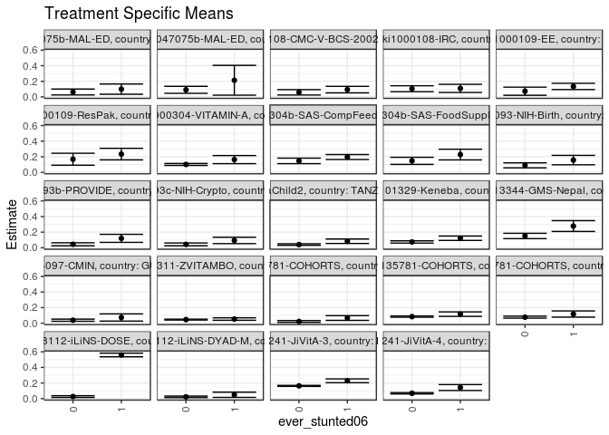

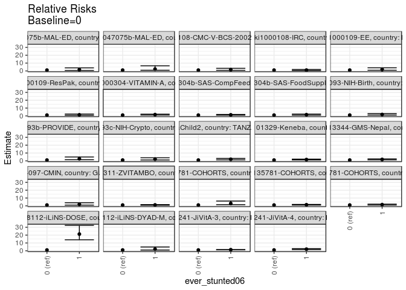

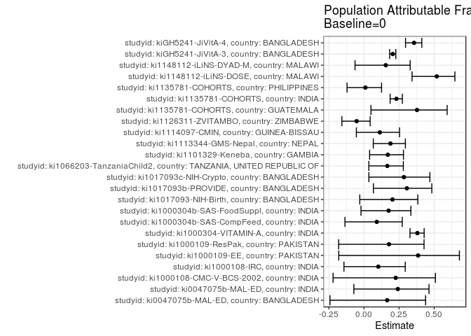

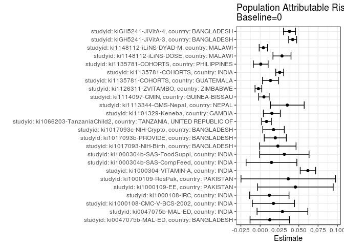

## Results Table

### Parameter: TSM

| studyid | country | intervention_level | baseline_level | estimate | ci_lower | ci_upper |
| --- | --- | --- | --- | --- | --- | --- |
| ki0047075b-MAL-ED | BANGLADESH | 0 | NA | 0.0628931 | 0.0250788 | 0.1007074 |
| ki0047075b-MAL-ED | BANGLADESH | 1 | NA | 0.1000000 | 0.0341228 | 0.1658772 |
| ki0047075b-MAL-ED | INDIA | 0 | NA | 0.0908123 | 0.0460673 | 0.1355573 |
| ki0047075b-MAL-ED | INDIA | 1 | NA | 0.2133940 | 0.0222517 | 0.4045363 |
| ki1000108-CMC-V-BCS-2002 | INDIA | 0 | NA | 0.0589122 | 0.0243824 | 0.0934421 |
| ki1000108-CMC-V-BCS-2002 | INDIA | 1 | NA | 0.0935512 | 0.0518391 | 0.1352633 |
| ki1000108-IRC | INDIA | 0 | NA | 0.1051705 | 0.0671707 | 0.1431702 |
| ki1000108-IRC | INDIA | 1 | NA | 0.1094167 | 0.0571005 | 0.1617329 |
| ki1000109-EE | PAKISTAN | 0 | NA | 0.0729167 | 0.0208366 | 0.1249967 |
| ki1000109-EE | PAKISTAN | 1 | NA | 0.1345455 | 0.0941600 | 0.1749309 |
| ki1000109-ResPak | PAKISTAN | 0 | NA | 0.1681528 | 0.0916108 | 0.2446949 |
| ki1000109-ResPak | PAKISTAN | 1 | NA | 0.2339840 | 0.1598182 | 0.3081497 |
| ki1000304-VITAMIN-A | INDIA | 0 | NA | 0.1009026 | 0.0884287 | 0.1133764 |
| ki1000304-VITAMIN-A | INDIA | 1 | NA | 0.1634305 | 0.1114766 | 0.2153844 |
| ki1000304b-SAS-CompFeed | INDIA | 0 | NA | 0.1465996 | 0.1113670 | 0.1818321 |
| ki1000304b-SAS-CompFeed | INDIA | 1 | NA | 0.1966040 | 0.1651466 | 0.2280613 |
| ki1000304b-SAS-FoodSuppl | INDIA | 0 | NA | 0.1474384 | 0.1019659 | 0.1929109 |
| ki1000304b-SAS-FoodSuppl | INDIA | 1 | NA | 0.2282232 | 0.1597294 | 0.2967169 |
| ki1017093-NIH-Birth | BANGLADESH | 0 | NA | 0.0899440 | 0.0577715 | 0.1221165 |
| ki1017093-NIH-Birth | BANGLADESH | 1 | NA | 0.1573614 | 0.0968298 | 0.2178930 |
| ki1017093b-PROVIDE | BANGLADESH | 0 | NA | 0.0445499 | 0.0254815 | 0.0636183 |
| ki1017093b-PROVIDE | BANGLADESH | 1 | NA | 0.1208243 | 0.0691784 | 0.1724702 |
| ki1017093c-NIH-Crypto | BANGLADESH | 0 | NA | 0.0436210 | 0.0255348 | 0.0617072 |
| ki1017093c-NIH-Crypto | BANGLADESH | 1 | NA | 0.0937235 | 0.0527886 | 0.1346584 |
| ki1066203-TanzaniaChild2 | TANZANIA, UNITED REPUBLIC OF | 0 | NA | 0.0412359 | 0.0311007 | 0.0513711 |
| ki1066203-TanzaniaChild2 | TANZANIA, UNITED REPUBLIC OF | 1 | NA | 0.0836960 | 0.0552129 | 0.1121791 |
| ki1101329-Keneba | GAMBIA | 0 | NA | 0.0744673 | 0.0599888 | 0.0889458 |
| ki1101329-Keneba | GAMBIA | 1 | NA | 0.1220804 | 0.0938626 | 0.1502982 |
| ki1113344-GMS-Nepal | NEPAL | 0 | NA | 0.1514732 | 0.1174386 | 0.1855079 |
| ki1113344-GMS-Nepal | NEPAL | 1 | NA | 0.2784453 | 0.2091562 | 0.3477344 |
| ki1114097-CMIN | GUINEA-BISSAU | 0 | NA | 0.0384106 | 0.0246941 | 0.0521271 |
| ki1114097-CMIN | GUINEA-BISSAU | 1 | NA | 0.0731707 | 0.0271226 | 0.1192188 |
| ki1126311-ZVITAMBO | ZIMBABWE | 0 | NA | 0.0461046 | 0.0404813 | 0.0517280 |
| ki1126311-ZVITAMBO | ZIMBABWE | 1 | NA | 0.0531953 | 0.0375094 | 0.0688812 |
| ki1135781-COHORTS | GUATEMALA | 0 | NA | 0.0220114 | 0.0099647 | 0.0340582 |
| ki1135781-COHORTS | GUATEMALA | 1 | NA | 0.0663409 | 0.0359253 | 0.0967565 |
| ki1135781-COHORTS | INDIA | 0 | NA | 0.0843806 | 0.0765787 | 0.0921825 |
| ki1135781-COHORTS | INDIA | 1 | NA | 0.1164095 | 0.0877421 | 0.1450769 |
| ki1135781-COHORTS | PHILIPPINES | 0 | NA | 0.0772320 | 0.0643704 | 0.0900935 |
| ki1135781-COHORTS | PHILIPPINES | 1 | NA | 0.1175855 | 0.0776986 | 0.1574724 |
| ki1148112-iLiNS-DOSE | MALAWI | 0 | NA | 0.0262517 | 0.0152607 | 0.0372427 |
| ki1148112-iLiNS-DOSE | MALAWI | 1 | NA | 0.5595586 | 0.5360912 | 0.5830260 |
| ki1148112-iLiNS-DYAD-M | MALAWI | 0 | NA | 0.0225989 | 0.0128025 | 0.0323952 |
| ki1148112-iLiNS-DYAD-M | MALAWI | 1 | NA | 0.0493827 | 0.0160026 | 0.0827629 |
| kiGH5241-JiVitA-3 | BANGLADESH | 0 | NA | 0.1635226 | 0.1569468 | 0.1700983 |
| kiGH5241-JiVitA-3 | BANGLADESH | 1 | NA | 0.2284275 | 0.2042269 | 0.2526280 |
| kiGH5241-JiVitA-4 | BANGLADESH | 0 | NA | 0.0685825 | 0.0601440 | 0.0770209 |
| kiGH5241-JiVitA-4 | BANGLADESH | 1 | NA | 0.1422382 | 0.1041996 | 0.1802769 |

### Parameter: E(Y)

| studyid | country | intervention_level | baseline_level | estimate | ci_lower | ci_upper |
| --- | --- | --- | --- | --- | --- | --- |
| ki0047075b-MAL-ED | BANGLADESH | NA | NA | 0.0753138 | 0.0417869 | 0.1088408 |
| ki0047075b-MAL-ED | INDIA | NA | NA | 0.1196581 | 0.0779840 | 0.1613323 |
| ki1000108-CMC-V-BCS-2002 | INDIA | NA | NA | 0.0760870 | 0.0489610 | 0.1032130 |
| ki1000108-IRC | INDIA | NA | NA | 0.1170732 | 0.0859146 | 0.1482317 |
| ki1000109-EE | PAKISTAN | NA | NA | 0.1185984 | 0.0856546 | 0.1515422 |
| ki1000109-ResPak | PAKISTAN | NA | NA | 0.2045455 | 0.1511224 | 0.2579685 |
| ki1000304-VITAMIN-A | INDIA | NA | NA | 0.1627604 | 0.1476839 | 0.1778369 |
| ki1000304b-SAS-CompFeed | INDIA | NA | NA | 0.1612426 | 0.1416314 | 0.1808538 |
| ki1000304b-SAS-FoodSuppl | INDIA | NA | NA | 0.1787565 | 0.1404842 | 0.2170288 |
| ki1017093-NIH-Birth | BANGLADESH | NA | NA | 0.1128405 | 0.0854611 | 0.1402198 |
| ki1017093b-PROVIDE | BANGLADESH | NA | NA | 0.0641447 | 0.0446535 | 0.0836359 |
| ki1017093c-NIH-Crypto | BANGLADESH | NA | NA | 0.0609418 | 0.0434802 | 0.0784034 |
| ki1066203-TanzaniaChild2 | TANZANIA, UNITED REPUBLIC OF | NA | NA | 0.0494534 | 0.0397554 | 0.0591514 |
| ki1101329-Keneba | GAMBIA | NA | NA | 0.0896333 | 0.0777184 | 0.1015482 |
| ki1113344-GMS-Nepal | NEPAL | NA | NA | 0.1866438 | 0.1550166 | 0.2182711 |
| ki1114097-CMIN | GUINEA-BISSAU | NA | NA | 0.0432802 | 0.0298127 | 0.0567476 |
| ki1126311-ZVITAMBO | ZIMBABWE | NA | NA | 0.0438186 | 0.0394817 | 0.0481556 |
| ki1135781-COHORTS | GUATEMALA | NA | NA | 0.0353591 | 0.0233199 | 0.0473983 |
| ki1135781-COHORTS | INDIA | NA | NA | 0.1096840 | 0.1017209 | 0.1176470 |
| ki1135781-COHORTS | PHILIPPINES | NA | NA | 0.0779833 | 0.0679723 | 0.0879943 |
| ki1148112-iLiNS-DOSE | MALAWI | NA | NA | 0.0545229 | 0.0388484 | 0.0701975 |
| ki1148112-iLiNS-DYAD-M | MALAWI | NA | NA | 0.0267431 | 0.0169662 | 0.0365200 |
| kiGH5241-JiVitA-3 | BANGLADESH | NA | NA | 0.2056324 | 0.1980748 | 0.2131900 |
| kiGH5241-JiVitA-4 | BANGLADESH | NA | NA | 0.1065428 | 0.0957758 | 0.1173098 |

### Parameter: RR

| studyid | country | intervention_level | baseline_level | estimate | ci_lower | ci_upper |
| --- | --- | --- | --- | --- | --- | --- |
| ki0047075b-MAL-ED | BANGLADESH | 0 | 0 | 1.000000 | 1.0000000 | 1.000000 |
| ki0047075b-MAL-ED | BANGLADESH | 1 | 0 | 1.590000 | 0.6517059 | 3.879204 |
| ki0047075b-MAL-ED | INDIA | 0 | 0 | 1.000000 | 1.0000000 | 1.000000 |
| ki0047075b-MAL-ED | INDIA | 1 | 0 | 2.349836 | 0.8435285 | 6.545988 |
| ki1000108-CMC-V-BCS-2002 | INDIA | 0 | 0 | 1.000000 | 1.0000000 | 1.000000 |
| ki1000108-CMC-V-BCS-2002 | INDIA | 1 | 0 | 1.587975 | 0.7598342 | 3.318706 |
| ki1000108-IRC | INDIA | 0 | 0 | 1.000000 | 1.0000000 | 1.000000 |
| ki1000108-IRC | INDIA | 1 | 0 | 1.040375 | 0.5704867 | 1.897293 |
| ki1000109-EE | PAKISTAN | 0 | 0 | 1.000000 | 1.0000000 | 1.000000 |
| ki1000109-EE | PAKISTAN | 1 | 0 | 1.845195 | 0.8503012 | 4.004162 |
| ki1000109-ResPak | PAKISTAN | 0 | 0 | 1.000000 | 1.0000000 | 1.000000 |
| ki1000109-ResPak | PAKISTAN | 1 | 0 | 1.391496 | 0.7994263 | 2.422062 |
| ki1000304-VITAMIN-A | INDIA | 0 | 0 | 1.000000 | 1.0000000 | 1.000000 |
| ki1000304-VITAMIN-A | INDIA | 1 | 0 | 1.619687 | 1.1509933 | 2.279236 |
| ki1000304b-SAS-CompFeed | INDIA | 0 | 0 | 1.000000 | 1.0000000 | 1.000000 |
| ki1000304b-SAS-CompFeed | INDIA | 1 | 0 | 1.341095 | 0.9804474 | 1.834403 |
| ki1000304b-SAS-FoodSuppl | INDIA | 0 | 0 | 1.000000 | 1.0000000 | 1.000000 |
| ki1000304b-SAS-FoodSuppl | INDIA | 1 | 0 | 1.547922 | 1.0066103 | 2.380328 |
| ki1017093-NIH-Birth | BANGLADESH | 0 | 0 | 1.000000 | 1.0000000 | 1.000000 |
| ki1017093-NIH-Birth | BANGLADESH | 1 | 0 | 1.749549 | 1.0339195 | 2.960503 |
| ki1017093b-PROVIDE | BANGLADESH | 0 | 0 | 1.000000 | 1.0000000 | 1.000000 |
| ki1017093b-PROVIDE | BANGLADESH | 1 | 0 | 2.712111 | 1.4807671 | 4.967388 |
| ki1017093c-NIH-Crypto | BANGLADESH | 0 | 0 | 1.000000 | 1.0000000 | 1.000000 |
| ki1017093c-NIH-Crypto | BANGLADESH | 1 | 0 | 2.148588 | 1.1769571 | 3.922344 |
| ki1066203-TanzaniaChild2 | TANZANIA, UNITED REPUBLIC OF | 0 | 0 | 1.000000 | 1.0000000 | 1.000000 |
| ki1066203-TanzaniaChild2 | TANZANIA, UNITED REPUBLIC OF | 1 | 0 | 2.029687 | 1.3333369 | 3.089714 |
| ki1101329-Keneba | GAMBIA | 0 | 0 | 1.000000 | 1.0000000 | 1.000000 |
| ki1101329-Keneba | GAMBIA | 1 | 0 | 1.639382 | 1.2138037 | 2.214176 |
| ki1113344-GMS-Nepal | NEPAL | 0 | 0 | 1.000000 | 1.0000000 | 1.000000 |
| ki1113344-GMS-Nepal | NEPAL | 1 | 0 | 1.838247 | 1.3157463 | 2.568241 |
| ki1114097-CMIN | GUINEA-BISSAU | 0 | 0 | 1.000000 | 1.0000000 | 1.000000 |
| ki1114097-CMIN | GUINEA-BISSAU | 1 | 0 | 1.904962 | 0.9239299 | 3.927658 |
| ki1126311-ZVITAMBO | ZIMBABWE | 0 | 0 | 1.000000 | 1.0000000 | 1.000000 |
| ki1126311-ZVITAMBO | ZIMBABWE | 1 | 0 | 1.153795 | 0.8388871 | 1.586916 |
| ki1135781-COHORTS | GUATEMALA | 0 | 0 | 1.000000 | 1.0000000 | 1.000000 |
| ki1135781-COHORTS | GUATEMALA | 1 | 0 | 3.013930 | 1.4770088 | 6.150114 |
| ki1135781-COHORTS | INDIA | 0 | 0 | 1.000000 | 1.0000000 | 1.000000 |
| ki1135781-COHORTS | INDIA | 1 | 0 | 1.379576 | 1.0612471 | 1.793391 |
| ki1135781-COHORTS | PHILIPPINES | 0 | 0 | 1.000000 | 1.0000000 | 1.000000 |
| ki1135781-COHORTS | PHILIPPINES | 1 | 0 | 1.522498 | 1.0444650 | 2.219318 |
| ki1148112-iLiNS-DOSE | MALAWI | 0 | 0 | 1.000000 | 1.0000000 | 1.000000 |
| ki1148112-iLiNS-DOSE | MALAWI | 1 | 0 | 21.315137 | 14.0362667 | 32.368655 |
| ki1148112-iLiNS-DYAD-M | MALAWI | 0 | 0 | 1.000000 | 1.0000000 | 1.000000 |
| ki1148112-iLiNS-DYAD-M | MALAWI | 1 | 0 | 2.185185 | 0.9789204 | 4.877857 |
| kiGH5241-JiVitA-3 | BANGLADESH | 0 | 0 | 1.000000 | 1.0000000 | 1.000000 |
| kiGH5241-JiVitA-3 | BANGLADESH | 1 | 0 | 1.396917 | 1.2473027 | 1.564478 |
| kiGH5241-JiVitA-4 | BANGLADESH | 0 | 0 | 1.000000 | 1.0000000 | 1.000000 |
| kiGH5241-JiVitA-4 | BANGLADESH | 1 | 0 | 2.073973 | 1.5496177 | 2.775759 |

### Parameter: PAR

| studyid | country | intervention_level | baseline_level | estimate | ci_lower | ci_upper |
| --- | --- | --- | --- | --- | --- | --- |
| ki0047075b-MAL-ED | BANGLADESH | 0 | NA | 0.0124207 | -0.0131019 | 0.0379434 |
| ki0047075b-MAL-ED | INDIA | 0 | NA | 0.0288458 | -0.0040490 | 0.0617407 |
| ki1000108-CMC-V-BCS-2002 | INDIA | 0 | NA | 0.0171747 | -0.0101507 | 0.0445001 |
| ki1000108-IRC | INDIA | 0 | NA | 0.0119027 | -0.0135796 | 0.0373850 |
| ki1000109-EE | PAKISTAN | 0 | NA | 0.0456817 | -0.0032462 | 0.0946096 |
| ki1000109-ResPak | PAKISTAN | 0 | NA | 0.0363926 | -0.0248469 | 0.0976321 |
| ki1000304-VITAMIN-A | INDIA | 0 | NA | 0.0618579 | 0.0518896 | 0.0718261 |
| ki1000304b-SAS-CompFeed | INDIA | 0 | NA | 0.0146430 | -0.0182411 | 0.0475272 |
| ki1000304b-SAS-FoodSuppl | INDIA | 0 | NA | 0.0313181 | -0.0006767 | 0.0633128 |
| ki1017093-NIH-Birth | BANGLADESH | 0 | NA | 0.0228965 | -0.0006912 | 0.0464841 |
| ki1017093b-PROVIDE | BANGLADESH | 0 | NA | 0.0195948 | 0.0052643 | 0.0339254 |
| ki1017093c-NIH-Crypto | BANGLADESH | 0 | NA | 0.0173209 | 0.0033650 | 0.0312767 |
| ki1066203-TanzaniaChild2 | TANZANIA, UNITED REPUBLIC OF | 0 | NA | 0.0082175 | 0.0019604 | 0.0144746 |
| ki1101329-Keneba | GAMBIA | 0 | NA | 0.0151660 | 0.0041743 | 0.0261578 |
| ki1113344-GMS-Nepal | NEPAL | 0 | NA | 0.0351706 | 0.0133268 | 0.0570144 |
| ki1114097-CMIN | GUINEA-BISSAU | 0 | NA | 0.0048696 | -0.0019086 | 0.0116478 |
| ki1126311-ZVITAMBO | ZIMBABWE | 0 | NA | -0.0022860 | -0.0066498 | 0.0020778 |
| ki1135781-COHORTS | GUATEMALA | 0 | NA | 0.0133477 | 0.0030438 | 0.0236516 |
| ki1135781-COHORTS | INDIA | 0 | NA | 0.0253034 | 0.0202001 | 0.0304066 |
| ki1135781-COHORTS | PHILIPPINES | 0 | NA | 0.0007513 | -0.0088291 | 0.0103318 |
| ki1148112-iLiNS-DOSE | MALAWI | 0 | NA | 0.0282712 | 0.0165825 | 0.0399599 |
| ki1148112-iLiNS-DYAD-M | MALAWI | 0 | NA | 0.0041442 | -0.0012704 | 0.0095588 |
| kiGH5241-JiVitA-3 | BANGLADESH | 0 | NA | 0.0421099 | 0.0369744 | 0.0472453 |
| kiGH5241-JiVitA-4 | BANGLADESH | 0 | NA | 0.0379603 | 0.0301600 | 0.0457606 |

### Parameter: PAF

| studyid | country | intervention_level | baseline_level | estimate | ci_lower | ci_upper |
| --- | --- | --- | --- | --- | --- | --- |
| ki0047075b-MAL-ED | BANGLADESH | 0 | NA | 0.1649196 | -0.2426794 | 0.4388261 |
| ki0047075b-MAL-ED | INDIA | 0 | NA | 0.2410686 | -0.0724573 | 0.4629373 |
| ki1000108-CMC-V-BCS-2002 | INDIA | 0 | NA | 0.2257248 | -0.2204520 | 0.5087868 |
| ki1000108-IRC | INDIA | 0 | NA | 0.1016689 | -0.1429396 | 0.2939270 |
| ki1000109-EE | PAKISTAN | 0 | NA | 0.3851799 | -0.1799604 | 0.6796471 |
| ki1000109-ResPak | PAKISTAN | 0 | NA | 0.1779194 | -0.1808236 | 0.4276737 |
| ki1000304-VITAMIN-A | INDIA | 0 | NA | 0.3800547 | 0.3275937 | 0.4284227 |
| ki1000304b-SAS-CompFeed | INDIA | 0 | NA | 0.0908136 | -0.1357730 | 0.2721962 |
| ki1000304b-SAS-FoodSuppl | INDIA | 0 | NA | 0.1751997 | -0.0215509 | 0.3340561 |
| ki1017093-NIH-Birth | BANGLADESH | 0 | NA | 0.2029100 | -0.0301606 | 0.3832492 |
| ki1017093b-PROVIDE | BANGLADESH | 0 | NA | 0.3054784 | 0.0668640 | 0.4830761 |
| ki1017093c-NIH-Crypto | BANGLADESH | 0 | NA | 0.2842196 | 0.0345606 | 0.4693178 |
| ki1066203-TanzaniaChild2 | TANZANIA, UNITED REPUBLIC OF | 0 | NA | 0.1661665 | 0.0342424 | 0.2800696 |
| ki1101329-Keneba | GAMBIA | 0 | NA | 0.1692008 | 0.0399834 | 0.2810255 |
| ki1113344-GMS-Nepal | NEPAL | 0 | NA | 0.1884370 | 0.0660683 | 0.2947722 |
| ki1114097-CMIN | GUINEA-BISSAU | 0 | NA | 0.1125131 | -0.0544330 | 0.2530269 |
| ki1126311-ZVITAMBO | ZIMBABWE | 0 | NA | -0.0521692 | -0.1576985 | 0.0437407 |
| ki1135781-COHORTS | GUATEMALA | 0 | NA | 0.3774895 | 0.0494291 | 0.5923299 |
| ki1135781-COHORTS | INDIA | 0 | NA | 0.2306934 | 0.1858805 | 0.2730397 |
| ki1135781-COHORTS | PHILIPPINES | 0 | NA | 0.0096346 | -0.1209759 | 0.1250271 |
| ki1148112-iLiNS-DOSE | MALAWI | 0 | NA | 0.5185200 | 0.3422286 | 0.6475629 |
| ki1148112-iLiNS-DYAD-M | MALAWI | 0 | NA | 0.1549637 | -0.0640709 | 0.3289109 |
| kiGH5241-JiVitA-3 | BANGLADESH | 0 | NA | 0.2047822 | 0.1824420 | 0.2265121 |
| kiGH5241-JiVitA-4 | BANGLADESH | 0 | NA | 0.3562917 | 0.2957959 | 0.4115906 |